# Tidy Tuesday

# Tidy Tuesday

The Tidy Tuesday project is designed to encourage R users to experiment with different ways to explore and visualise datasets.

Every week a new dataset is made available and folks share their creations on Twitter.

Datasets cover all sorts of topics:

- TV Shows
- Demographic data
- Video Games
- Political data

# Friends Week

I really enjoyed the Friends week of Tidy Tuesday, there were all sorts of visualisations shared on Twitter.

> I know it's not Tuesday, but I had some time this weekend and attempted my first contribution to [#TidyTuesday](https://twitter.com/hashtag/TidyTuesday?src=hash&ref_src=twsrc%5Etfw). With the data including transcripts from the TV show Friends, I wanted to figure out how many times Joey (or anyone else) actually said: “How you doin'?”. 1/4 [pic.twitter.com/o113fh82pQ](https://t.co/o113fh82pQ)

> — Sonja Winter, PhD (@winterstat) [September 13, 2020](https://twitter.com/winterstat/status/1305283132388642816?ref_src=twsrc%5Etfw)

## Exploring the dataset

We can read in the dataset directly from GitHub:

```r
library(tidyverse)
friends <- readr::read_csv('https://raw.githubusercontent.com/rfordatascience/tidytuesday/master/data/2020/2020-09-08/friends.csv')
```

There are 700 unique speakers in the dataset! Unsurprisingly the titular friends are in the top 10 (as well as scene directions)

| Character | How many times the character speaks (in entire series) |
| --- | --- |
| Rachel Green | 9312 |
| Ross Geller | 9157 |
| Chandler Bing | 8465 |
| Monica Geller | 8441 |
| Joey Tribbiani | 8171 |
| Phoebe Buffay | 7501 |
| Scene Directions | 6063 |
| #ALL# | 347 |
| Mike Hannigan | 330 |
| Richard Burke | 281 |

### Season breakdown

Here’s the top 10 speakers by season

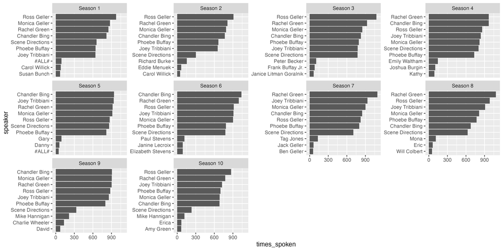